# Testing loading a package

## Statistical analyses

### Wild, urban population

For each bird, calculated the condition as a regression of mass and tarsus length, using the following formula: `Condit<-lm(Mass~Tarsus)`

```
##
## Call:
## lm(formula = Mass ~ Tarsus, data = fwild, na.action = na.exclude)
##
## Residuals:
##     Min      1Q  Median      3Q     Max
## -3.6770 -0.8184  0.0028  0.8000  3.4134
##
## Coefficients:
##             Estimate Std. Error t value Pr(>|t|)
## (Intercept)  10.4563     2.6209   3.990 9.44e-05 ***
## Tarsus        0.4438     0.1344   3.303  0.00114 **
## ---
## Signif. codes:  0 '***' 0.001 '**' 0.01 '*' 0.05 '.' 0.1 ' ' 1
##
## Residual standard error: 1.156 on 190 degrees of freedom
##   (30 observations deleted due to missingness)
## Multiple R-squared:  0.0543, Adjusted R-squared:  0.04932
## F-statistic: 10.91 on 1 and 190 DF,  p-value: 0.001143
```

Because some wild birds were recaptures and sampled more than once, I then used a random number generator in R to create a random ID and select one data point, randomly, from birds with more than one data point during the study. This then changed the sample size between the weeks. The table below shows the week # (first row) with sample size below.

```
##
##  0  1  2  3  4  5  6  7  8
## 14 16 23 18 15 21 19 17 18
```

The below graphs show the trend of body condition in the wild-caught birds over the course of the study.

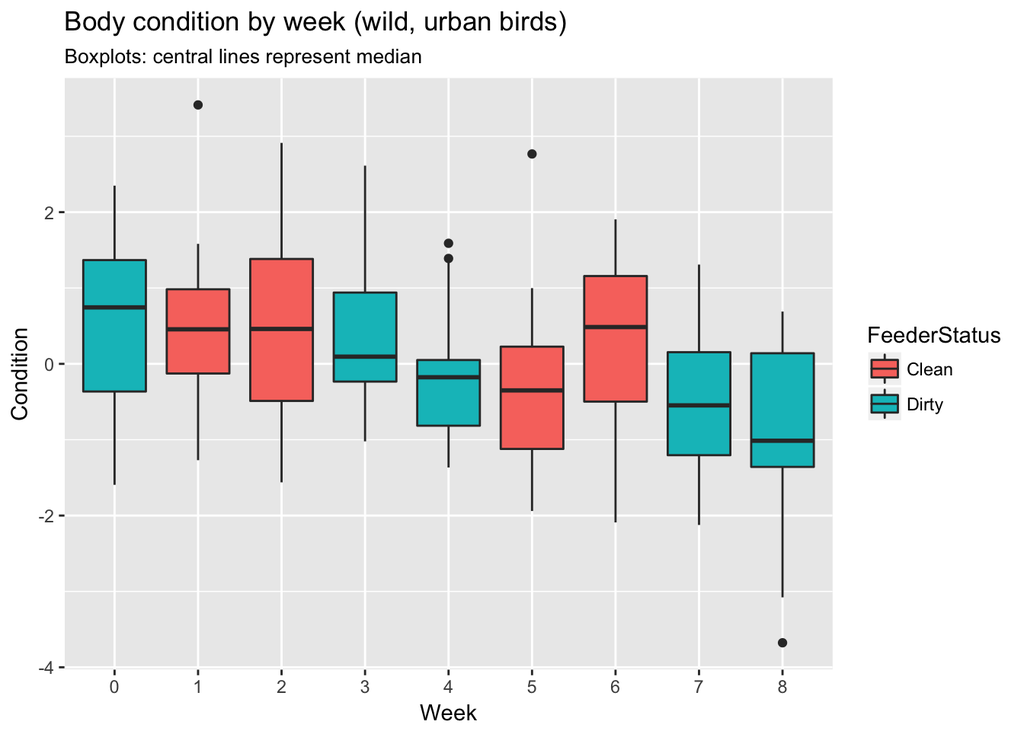

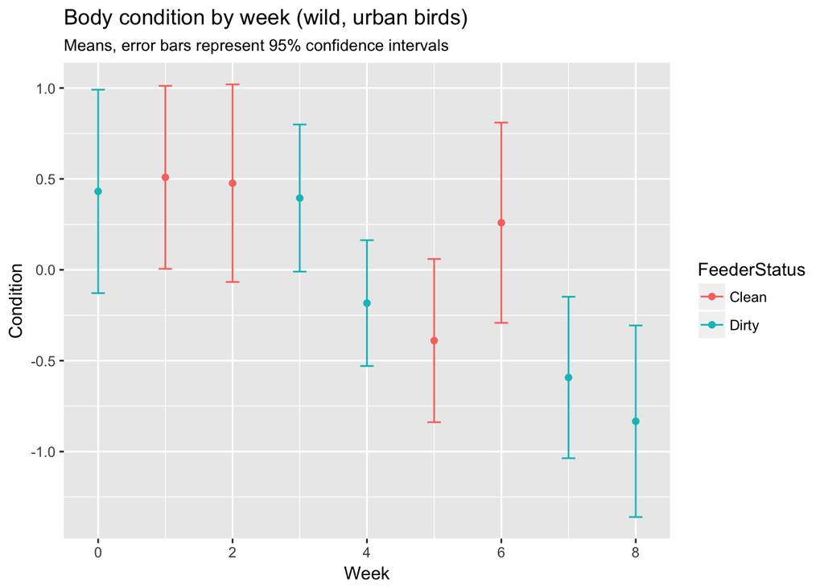

A type-II ANOVA, using unique bird IDs only (no recapture data included), shows a significant effect of week on body condition, but *not* feeder status. Additionally, there is no significant interaction between feeder status and week, suggesting the effect is of time, but not the feeder treatment “cycle” number.

```
## Anova Table (Type II tests)
##
## Response: Condition
##                    Sum Sq  Df F value    Pr(>F)
## FeederStatus        2.537   1  2.0550    0.1539
## Week               23.000   1 18.6331 2.979e-05 ***
## FeederStatus:Week   0.582   1  0.4713    0.4935
## Residuals         172.814 140
## ---
## Signif. codes:  0 '***' 0.001 '**' 0.01 '*' 0.05 '.' 0.1 ' ' 1
```

```
## fixed-effect model matrix is rank deficient so dropping 9 columns / coefficients
```

```
## Analysis of Deviance Table (Type II Wald chisquare tests)
##
## Response: Condition
##                     Chisq Df Pr(>Chisq)
## FeederStatus       2.7777  1    0.09558 .
## Week              78.2239  7   3.17e-14 ***
## FeederStatus:Week          0
## ---
## Signif. codes:  0 '***' 0.001 '**' 0.01 '*' 0.05 '.' 0.1 ' ' 1
```

```
## fixed-effect model matrix is rank deficient so dropping 1 column / coefficient
```